# Reliable Receivers: Projecting 2026 Fantasy-Relevant WRs with Decision Trees and GLM

Author

Varun Shetty

## Introduction

Winning in fantasy comes down to drafting players that produce consistently. Production for WRs can be volatile from season to season, and even week to week. Fantasy owners want to identify reliable receivers before the draft with the limited information they have from previous seasons

This project aims to identify the most valuable information and use it to predict the most draftable receivers for the 2026 class. It is important to note that there are a lot of other factors that may affect predicting a WRs production: injuries, incomplete rookie data, QB play, trades and roster depth. Nevertheless, this analysis mainly focuses on using general metrics unique to the receiver themselves.

The analysis is organized into four parts:

- **Dataset Construction** — building season-level features from Play By Play data
- **Exploratory Analysis** — understanding how usage and efficiency relate to outcomes
- **Modeling** — applying interpretable models (Decision Tree and GLM)
- **Predictions** — generating a forward-looking view of the 2026 class

**Dataset Construction**

### Data Pipeline

In order to predict the best receivers to draft, we need to identify and label the starting quality receivers (top 24 each season), and gather any metrics we could use to predict their success.

Using NFLReadR play-by-play data, I calculated the best fantasy seasons for WRs using full PPR scoring.

1. **Filter WRs and Pull Weekly Stats**
2. **Use Team Data to Break Down Target Share**
3. **Build Variables from Play-by-Play**
   - aDOT (average depth of target)
   - YAC (yards after catch) per reception
   - EPA (expected points added) per target
   - First Down Rate
   - Red-zone usage
4. **Sort by Tier (WR1 / WR2)**
   - WR1 = Top 12
   - WR2 = Top 24

**Show data pipeline**

```r
library(tidyverse)
library(nflreadr)
library(nflfastR)
library(gt)
library(scales)
library(DT)

seasons <- 2018:2025

# ----------------------------
# 1. Load Data
# ----------------------------
player_stats <- nflreadr::load_player_stats(seasons)
pbp <- nflreadr::load_pbp(seasons)

# ----------------------------
# 2. Build WR ID Reference
# ----------------------------
wr_ids <- player_stats %>%
  filter(season_type == "REG", position == "WR") %>%
  mutate(player_name = coalesce(player_display_name, player_name)) %>%
  distinct(season, player_id, player_name, team)

# ----------------------------
# 3. Weekly WR Fantasy + Targets
# ----------------------------
wr_weekly <- player_stats %>%
  filter(season_type == "REG", position == "WR") %>%
  mutate(player_name = coalesce(player_display_name, player_name)) %>%
  select(
    season,
    week,
    player_id,
    player_name,
    team,
    fantasy_points_ppr,
    targets
  )

stopifnot(nrow(wr_weekly) > 0)

# ----------------------------
# 4. Team Weekly Targets
# ----------------------------
team_weekly_targets <- player_stats %>%
  filter(season_type == "REG", !is.na(team)) %>%
  group_by(season, week, team) %>%
  summarise(
    team_targets = sum(targets, na.rm = TRUE),
    .groups = "drop"
  )

# ----------------------------
# 5. Clean PBP Receiver Data
# ----------------------------
pbp_wr <- pbp %>%
  filter(
    season_type == "REG",
    play_type == "pass",
    !is.na(receiver_player_id)
  ) %>%
  mutate(
    play_id_unique = paste(game_id, play_id, receiver_player_id, sep = "_")
  ) %>%
  distinct(play_id_unique, .keep_all = TRUE) %>%
  transmute(
    season,
    player_id = receiver_player_id,
    air_yards = coalesce(air_yards, 0),
    yac = coalesce(yards_after_catch, 0),
    rec_epa = coalesce(epa, 0),
    first_down = if_else(first_down_pass == 1, 1, 0),
    reception = if_else(complete_pass == 1, 1, 0),
    receiving_yards = if_else(complete_pass == 1, coalesce(yards_gained, 0), 0),
    rz_target = if_else(yardline_100 <= 20, 1, 0)
  ) %>%
  inner_join(
    wr_ids %>% distinct(season, player_id),
    by = c("season", "player_id")
  )

# ----------------------------
# 6. Aggregate PBP Features
# ----------------------------
pbp_features <- pbp_wr %>%
  group_by(season, player_id) %>%
  summarise(
    total_air_yards = sum(air_yards, na.rm = TRUE),
    total_yac = sum(yac, na.rm = TRUE),
    total_epa = sum(rec_epa, na.rm = TRUE),
    total_first_downs = sum(first_down, na.rm = TRUE),
    receptions = sum(reception, na.rm = TRUE),
    receiving_yards = sum(receiving_yards, na.rm = TRUE),
    rz_targets = sum(rz_target, na.rm = TRUE),
    pbp_targets = n(),
    .groups = "drop"
  )

# ----------------------------
# 7. Build Season-Level WR Features
# ----------------------------
wr_features <- wr_weekly %>%
  left_join(team_weekly_targets, by = c("season", "week", "team")) %>%
  group_by(season, player_id, player_name, team) %>%
  summarise(
    games = n_distinct(week),
    fantasy_points_ppr = sum(fantasy_points_ppr, na.rm = TRUE),
    player_targets = sum(targets, na.rm = TRUE),
    team_targets = sum(team_targets, na.rm = TRUE),
    targets_cv = if_else(
      mean(targets, na.rm = TRUE) > 0,
      sd(targets, na.rm = TRUE) / mean(targets, na.rm = TRUE),
      NA_real_
    ),
    .groups = "drop"
  ) %>%
  left_join(pbp_features, by = c("season", "player_id")) %>%
  mutate(
    target_share = if_else(team_targets > 0, player_targets / team_targets, NA_real_),
    targets_pg = if_else(games > 0, player_targets / games, NA_real_),
    adot = if_else(player_targets > 0, total_air_yards / player_targets, NA_real_),
    yac_per_reception = if_else(receptions > 0, total_yac / receptions, NA_real_),
    epa_per_target = if_else(player_targets > 0, total_epa / player_targets, NA_real_),
    first_down_rate = if_else(player_targets > 0, total_first_downs / player_targets, NA_real_),
    rz_targets = coalesce(rz_targets, 0L)
  )

# ----------------------------
# 8. Final WR Dataset + Labels
# ----------------------------
wr_season_dataset <- wr_features %>%
  filter(
    !is.na(player_targets),
    player_targets > 0
  ) %>%
  group_by(season) %>%
  arrange(desc(fantasy_points_ppr), .by_group = TRUE) %>%
  mutate(
    season_rank_ppr = row_number(desc(fantasy_points_ppr)),
    wr_tier = case_when(
      season_rank_ppr <= 12 ~ "WR1",
      season_rank_ppr <= 24 ~ "WR2",
      TRUE ~ "Other"
    )
  ) %>%
  ungroup() %>%
  select(
    season,
    player_id,
    player_name,
    team,
    games,
    fantasy_points_ppr,
    season_rank_ppr,
    wr_tier,
    target_share,
    targets_pg,
    targets_cv,
    adot,
    yac_per_reception,
    epa_per_target,
    first_down_rate,
    rz_targets,
    player_targets,
    total_air_yards,
    receptions,
    receiving_yards
  ) %>%
  arrange(desc(season), season_rank_ppr)

# ----------------------------
# 9. Modeling Dataset
# ----------------------------
wr_model_data <- wr_season_dataset %>%
  filter(
    !is.na(target_share),
    !is.na(targets_pg),
    !is.na(targets_cv),
    !is.na(adot),
    !is.na(yac_per_reception),
    !is.na(epa_per_target),
    !is.na(first_down_rate),
    !is.na(rz_targets),
    player_targets >= 20,
    adot >= 0,
    adot <= 30
  )
```

**Dataset**

| season | player_name | team | wr_tier | fantasy_points_ppr | season_rank_ppr | target_share | targets_pg | adot | yac_per_reception | epa_per_target | first_down_rate | rz_targets |
| --- | --- | --- | --- | --- | --- | --- | --- | --- | --- | --- | --- | --- |
| 2025 | Puka Nacua | LA | WR1 | 375 | 1 | 0.3029197080291971 | 10.375 | 9.433734939759036 | 5.162790697674419 | 0.696990413572364 | 0.4819277108433735 | 17 |
| 2025 | Jaxon Smith-Njigba | SEA | WR1 | 359.9 | 2 | 0.3582417582417582 | 9.588235294117647 | 11.24539877300614 | 4.436974789915967 | 0.556272061624747 | 0.4846625766871165 | 17 |
| 2025 | Amon-Ra St. Brown | DET | WR1 | 324 | 3 | 0.3127272727272727 | 10.11764705882353 | 8.081395348837209 | 4.871794871794871 | 0.323341373495086 | 0.4127906976744186 | 35 |
| 2025 | Ja'Marr Chase | CIN | WR1 | 313.6 | 4 | 0.3222996515679443 | 11.5625 | 8.486486486486486 | 5.12 | 0.2236728310473342 | 0.3945945945945946 | 22 |
| 2025 | George Pickens | DAL | WR1 | 291.9 | 5 | 0.2257001647446458 | 8.058823529411764 | 11.29197080291971 | 5.150537634408602 | 0.6400708852562343 | 0.5328467153284672 | 23 |
| 2025 | Chris Olave | NO | WR1 | 268 | 6 | 0.2937853107344633 | 9.75 | 11.80128205128205 | 2.89 | 0.2283933478378578 | 0.3397435897435898 | 15 |
| 2025 | Zay Flowers | BAL | WR1 | 243.3 | 7 | 0.2899262899262899 | 6.941176470588236 | 10.20338983050847 | 5.325581395348837 | 0.3930864632067983 | 0.4067796610169492 | 12 |
| 2025 | Nico Collins | HOU | WR1 | 226.2 | 8 | 0.2464065708418891 | 8 | 12.74166666666667 | 4.563380281690141 | 0.3275849943553485 | 0.4 | 19 |
| 2025 | Davante Adams | LA | WR1 | 222.9 | 9 | 0.2478260869565218 | 8.142857142857142 | 12.66666666666667 | 1.95 | 0.2371354533297739 | 0.4473684210526316 | 32 |
| 2025 | Michael Wilson | ARI | WR1 | 220.6 | 10 | 0.2042139384116694 | 7.411764705882353 | 11.92063492063492 | 3.5 | 0.2043823865267274 | 0.4047619047619048 | 17 |

[output cut: 1817 more lines]

## Exploratory Data Analysis

We compare WR1 (Top 12), WR2(Top 12-24), and Other receivers across key usage and efficiency metrics to understand what separates fantasy-relevant players.

### Feature Distribution by WR Tier

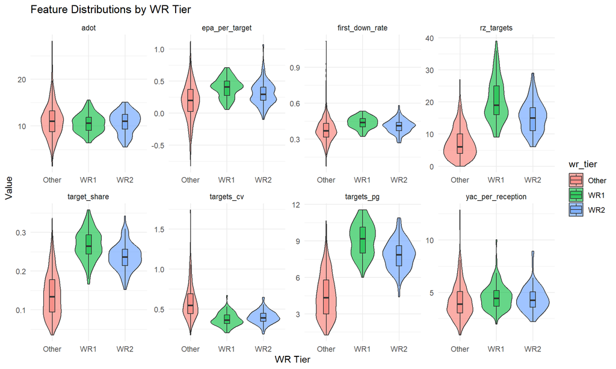

According to the violin plots above, the most clear difference between WR1s, WR2s,and the rest of the pack is **targets**. WR1s have significantly higher target share, redzone targets, and targets/game than WR2s,who also eclipse the rest of the field in target share.

WR1s also have smaller edges in median EPA(Expected Points Added) per target and first down rate. However, WR2s beat out WR1s in ADOT (Average Depth of Target) and are nearly even in YAC. This suggests that consistent, meaningful production leading to first downs and scoring opportunities is more important than deep catches or explosive YAC.

### Median Trends Year-to-Year

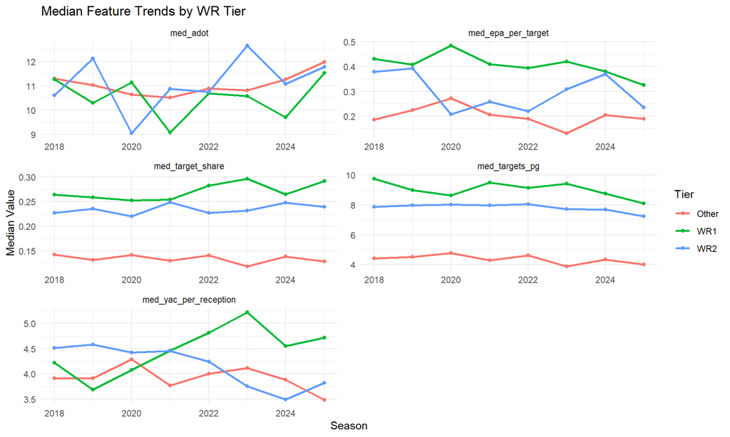

## Modeling

In order to make predictions of WRs 1 year in the future based on their previous year performance, we have to modify our data to separate each player’s performance by year(T) and tie it to their following year’s (T+1) performance

We then use the prior data(2018-2023) to create a decision tree and GLM (Generalized Linear Model)

### Decision Tree

The model shows that target share is the most important factor: players below ~22% are very unlikely to become top-24 receivers. Once a player earns enough volume, the model looks at efficiency (EPA per target and YAC) to separate average players from strong performers, with high efficiency pushing players toward top-24 outcomes. The colors represent predictions (blue = not top 24, green = top 24), and the numbers in each node show probabilities: for example, “.30 .70” means a 70% chance of being top 24, with the most important splits happening first at target share, then efficiency metrics. Interestingly, YAC has a negative impact on top 24 outcomes, as players with very high YAC are typically not in the top 24 category

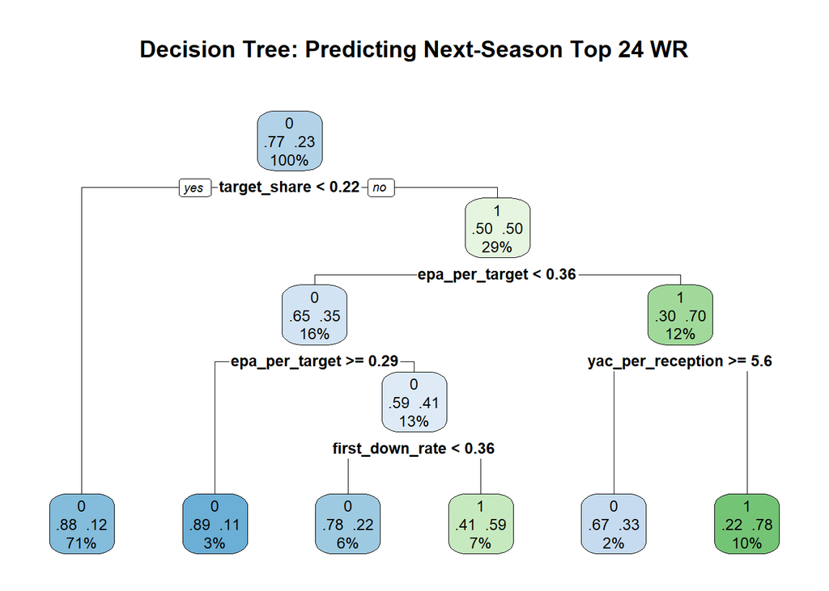

**Show Decision Tree evaluation**

TThe model correctly identifies most non-top-24 outcomes (68 true negatives) but struggles more with identifying true top-24 receivers, missing 12 of them. While it shows decent overall balance, the relatively higher false negatives suggest it is somewhat conservative in predicting breakout or high-performing seasons.

```
          Truth
Prediction  0  1
         0 68 12
         1  8 10
```

### GLM

**GLM Output**

This logistic regression estimates the probability of a WR being in the top 24 next year. Target share is the most statistically signifcant, while adot, and rz targets are statistically significant at p<0.10

```
Call:
glm(formula = next_top24_num ~ target_share + targets_cv + adot +
    yac_per_reception + epa_per_target + first_down_rate + rz_targets,
    family = binomial(), data = train_data)

Coefficients:
                  Estimate Std. Error z value Pr(>|z|)
(Intercept)       -6.09873    1.32042  -4.619 3.86e-06 ***
target_share      16.35365    2.99578   5.459 4.79e-08 ***
targets_cv        -0.47549    1.11462  -0.427   0.6697
adot               0.08106    0.04720   1.717   0.0859 .
yac_per_reception  0.11839    0.08746   1.354   0.1758
epa_per_target     1.26870    0.78292   1.620   0.1051
first_down_rate   -0.97606    1.93794  -0.504   0.6145
rz_targets         0.04131    0.02236   1.848   0.0646 .
---
Signif. codes:  0 '***' 0.001 '**' 0.01 '*' 0.05 '.' 0.1 ' ' 1

(Dispersion parameter for binomial family taken to be 1)

    Null deviance: 612.62  on 570  degrees of freedom
Residual deviance: 476.18  on 563  degrees of freedom
AIC: 492.18

Number of Fisher Scoring iterations: 5
```

**GLM Model Evaluation**

```
          Truth
Prediction  0  1
         0 69  8
         1  7 14
```

### Predictions for the 2025 Season vs Actual Results

| Player | Team | Season | GLM Prob | GLM Tier | GLM Pred | Tree Prob | Tree Pred | Actual | Actual Rank | Actual PPR |
| --- | --- | --- | --- | --- | --- | --- | --- | --- | --- | --- |
| A.J. Brown | PHI | 2024 | 84.0% | WR 1 (Strong Top24) | Top 24 | 78.0% | Top 24 | Top 24 | 11 | 220.3 |
| Malik Nabers | NYG | 2024 | 81.4% | WR 1 (Strong Top24) | Top 24 | 22.2% | Other | Other | 102 | 57.1 |
| Ja'Marr Chase | CIN | 2024 | 79.2% | WR 1 (Strong Top24) | Top 24 | 33.3% | Other | Top 24 | 4 | 313.6 |
| Justin Jefferson | MIN | 2024 | 78.4% | WR 1 (Strong Top24) | Top 24 | 78.0% | Top 24 | Top 24 | 21 | 201.5 |
| Davante Adams | NYJ | 2024 | 77.4% | WR 1 (Strong Top24) | Top 24 | 59.0% | Top 24 | Top 24 | 9 | 222.9 |
| Amon-Ra St. Brown | DET | 2024 | 68.9% | WR 1 (Strong Top24) | Top 24 | 78.0% | Top 24 | Top 24 | 3 | 324 |
| Puka Nacua | LA | 2024 | 68.8% | WR 1 (Strong Top24) | Top 24 | 33.3% | Other | Top 24 | 1 | 375 |
| Drake London | ATL | 2024 | 67.5% | WR 1 (Strong Top24) | Top 24 | 59.0% | Top 24 | Top 24 | 19 | 201.9 |
| DeVonta Smith | PHI | 2024 | 62.5% | WR 1 (Strong Top24) | Top 24 | 78.0% | Top 24 | Top 24 | 20 | 201.8 |
| Brian Thomas Jr. | JAX | 2024 | 60.6% | WR 1 (Strong Top24) | Top 24 | 33.3% | Other | Other | 40 | 138.8 |

[output cut: 88 more lines]

## 2026 WR Projections (GLM)

As the GLM model outperformed the decision tree in 2025, we plan to use it for 2026

The table below presents forward-looking projections for the 2026 season using a logistic regression model trained on historical data (through 2024).

Player features from the 2025 season are used to estimate the probability of each receiver finishing as a Top 24 fantasy option in 2026.

Players are ranked by predicted probability and grouped into tiers:

- **WR1**: Top 12
- **WR2**: Top 24
- **Flex**: Top 36
- **Other**: Remaining players

Notably, Jakobi Meyers- from both teams appears, and we will have to account for possible injuries, suspensions, arrests ETC. We also need to factor in rookie, sophomore upside, as well as trade and changing depth charts

| Rank | Player | Team | Tier | GLM Probability | Target Share | Targets/Game | aDOT | YAC/Rec | EPA/Target |
| --- | --- | --- | --- | --- | --- | --- | --- | --- | --- |
| 1 | Jaxon Smith-Njigba | SEA | WR1 | 85.4% | 35.8% | 9.6 | 11.2 | 4.4 | 0.56 |
| 2 | Amon-Ra St. Brown | DET | WR1 | 81.6% | 31.3% | 10.1 | 8.1 | 4.9 | 0.32 |
| 3 | Ja'Marr Chase | CIN | WR1 | 78.0% | 32.2% | 11.6 | 8.5 | 5.1 | 0.22 |
| 4 | Puka Nacua | LA | WR1 | 77.5% | 30.3% | 10.4 | 9.4 | 5.2 | 0.7 |
| 5 | Rashee Rice | KC | WR1 | 62.7% | 28.7% | 9.8 | 4.3 | 7.8 | 0.21 |
| 6 | Drake London | ATL | WR1 | 61.8% | 30.4% | 9.3 | 10.9 | 3.4 | 0.22 |
| 7 | Chris Olave | NO | WR1 | 59.5% | 29.4% | 9.8 | 11.8 | 2.9 | 0.23 |
| 8 | Justin Jefferson | MIN | WR1 | 57.5% | 30.1% | 8.3 | 10.2 | 5.4 | -0.1 |
| 9 | Davante Adams | LA | WR1 | 56.1% | 24.8% | 8.1 | 12.7 | 2 | 0.24 |
| 10 | George Pickens | DAL | WR1 | 55.3% | 22.6% | 8.1 | 11.3 | 5.2 | 0.64 |

[output cut: 40 more lines]